# CRISPR-Cas9 drug-perturbation analysis report

Published

November 12, 2025

## Synopsis

- This report summarizes the analysis of a CRISPR-Cas9 pooled screen investigating the effects of the drug **FGF401** on gene perturbations in a cellular model (**RMS559**). The CRISPR library used in this screen targets a total of:
  - **n = 2,322 genes**
  - **n = 23,064 sgRNAs**,
  - **n = 1,496** non-targeting control sgRNAs.
- The analysis reported here includes quality control assessments of the sgRNA sequencing data, as well as identification of gene perturbation effects in response to drug treatment.

### CRISPR-Cas9 library description

- The CRISPR library used in this screen is designed to target a comprehensive set of genes relevant to the biological context under investigation. Each gene is targeted by multiple sgRNAs to ensure robust perturbation effects. The library also includes non-targeting control sgRNAs to facilitate normalization and assessment of non-specific effects.

**Genes with few sgRNAs**

Some genes in the library have a relatively low number of sgRNAs (i.e., less than 10), as indicated in the table below. Caution should be exercised when interpreting results for these genes, as the limited number of sgRNAs may affect the robustness of the perturbation effects observed.

|  | SYMBOL | GENENAME | CRISPR_LIBRARY | NUM_GUIDES | ENSEMBL_GENE_ID |
| --- | --- | --- | --- | --- | --- |
| 1 | SGK3 | serum/glucocorticoid regulated kinase family member 3 | Bassik - Drug targets, kinases, phosphatases (DTKP) | 1 | ENSG00000104205 |
| 2 | VAMP2 | vesicle associated membrane protein 2 | Bassik - Drug targets, kinases, phosphatases (DTKP) | 1 | ENSG00000220205 |
| 3 | NDUFA11 | NADH:ubiquinone oxidoreductase subunit A11 | Bassik - Drug targets, kinases, phosphatases (DTKP) | 2 | ENSG00000174886 |
| 4 | NME1 | NME/NM23 nucleoside diphosphate kinase 1 | Bassik - Drug targets, kinases, phosphatases (DTKP) | 2 | ENSG00000239672 |
| 5 | CKMT1B | creatine kinase, mitochondrial 1B | Bassik - Drug targets, kinases, phosphatases (DTKP) | 3 | ENSG00000237289 |
| 6 | CKS1B | CDC28 protein kinase regulatory subunit 1B | Bassik - Drug targets, kinases, phosphatases (DTKP) | 3 | ENSG00000173207 |
| 7 | PYCR2 | pyrroline-5-carboxylate reductase 2 | Bassik - Drug targets, kinases, phosphatases (DTKP) | 3 | ENSG00000143811 |
| 8 | RSKR | ribosomal protein S6 kinase related | Bassik - Drug targets, kinases, phosphatases (DTKP) | 3 | ENSG00000167524 |
| 9 | AMY1A | amylase alpha 1A | Bassik - Drug targets, kinases, phosphatases (DTKP) | 4 | ENSG00000237763 |
| 10 | ARPC4 | actin related protein 2/3 complex subunit 4 | Bassik - Drug targets, kinases, phosphatases (DTKP) | 4 | ENSG00000241553 |

[output cut: 2312 more lines]

## Data quality control

Key summary statistics - sequencing

| file | timepoint | treatment | total_reads | mapped | percentage | zerocounts | gini_index |
| --- | --- | --- | --- | --- | --- | --- | --- |
| T0.fastq.gz | T0 | T0 | 5805059 | 4998589 | 0.8611 | 351 | 0.1091 |
| T4_DMSO.fastq.gz | T4 | DMSO | 5488046 | 4733508 | 0.8625 | 648 | 0.1487 |
| T4_FGF401.fastq.gz | T4 | FGF401 | 5861644 | 5031533 | 0.8584 | 636 | 0.1459 |
| T10_DMSO.fastq.gz | T10 | DMSO | 6789771 | 5836187 | 0.8596 | 1504 | 0.2206 |
| T10_FGF401.fastq.gz | T10 | FGF401 | 7037025 | 6050223 | 0.8598 | 1206 | 0.1985 |
| T14_DMSO.fastq.gz | T14 | DMSO | 6345379 | 5425258 | 0.8550 | 2471 | 0.2824 |
| T14_FGF401.fastq.gz | T14 | FGF401 | 6103707 | 5218315 | 0.8549 | 1995 | 0.2537 |

### Reads per sample - read mapping/assignment rate

- This plot shows the distribution of read counts per sample, indicating the relative proportion of sgRNA-mapped reads to the totality of reads sequenced per sample.

[interactive chart not shown]

### Library coverage and representation

- The plots below show the distribution of sgRNA read counts per sample, indicating the coverage and representation of sgRNAs in each sample.
- The first plot shows the distribution of read counts for the initial timepoint (**T0**), representing the baseline sgRNA abundance before any treatment.

**sgRNA Pseudocounts**

Note that all counts have been added a pseudocount of 1 prior to plotting, to allow visualization of sgRNAs with zero counts. This means that the minimum count value shown in the plots is 1.

[interactive chart not shown]

**Untreated samples (DMSO)**

[interactive chart not shown]

**Drug-treated samples (FGF401)**

[interactive chart not shown]

### Replicate & sample relationships

- Shown below are scatter plots showing observed log2-fold-change (**LFC**) in abundance of each sgRNA (or at the gene-level, using mean sgRNA abundance) for two conditions (drug *versus* T0 against control *versus* T0).

**Note**

The data underlying these fold-changes is raw and unmodeled, based on normalized count ratios. Separation of biological signal from sampling noise is not performed. So while these fold-changes are intuitive, they’re also “noisy” and can underestimate or overestimate true effects.

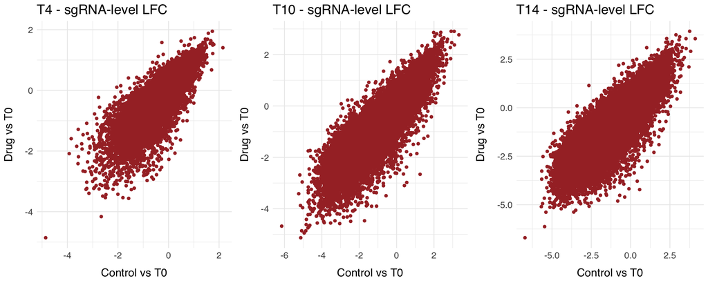

[interactive chart not shown]

- Principal component analysis (PCA) plot showing the relationships between samples based on sgRNA abundance profiles.

[interactive chart not shown]

## Modeling of gene perturbation effects

### MAGeCK-MLE analysis

- **MAGeCK-mle** is an algorithm that performs statistical modeling of gene perturbation effects in pooled CRISPR–Cas9 screens. It uses a maximum likelihood estimation (MLE) framework to estimate the effects of gene knockouts on cell fitness or other phenotypes, while accounting for various sources of variability in the data. **MAGeCK-mle** uses a measurement called *beta score* to call gene essentialities: a positive beta score means a gene is positively selected, and a negative beta score means a gene is negatively selected. It is similar to the term log fold change in differential expression.
- Here, we exploit the time-dependent measurements in drug-treated samples and controls **MAGeCK-mle** to calculate *beta scores* along three distinct dimensions:
  - **Common** effects across all timepoints (i.e., genes that affect cell fitness regardless of drug treatment)
  - **Late-vs-early** effects (i.e., genes that affect cell fitness differently at late timepoints (T10, T14) compared to early timepoints)
  - **Drug-treatment** effects (i.e., genes that affect cell fitness specifically in the presence of drug treatment)

**Hits with a p-value = 0**

In the plots below, some genes may have a p-value of exactly 0 due to limitations in numerical precision. These genes are indicated with a different shape in the plots.

**Common hits**

[interactive chart not shown]

|  | GENE | GENENAME | NUM_GUIDES | BETA | Z | P_VALUE | FDR |
| --- | --- | --- | --- | --- | --- | --- | --- |
| 1 | SOD1 | superoxide dismutase 1 | 10 | -1.2796 | -3.5622 | 0 | 0 |
| 2 | FNTB | farnesyltransferase, CAAX box, subunit beta | 6 | -1.1738 | -2.7857 | 0 | 0 |
| 3 | GAPDH | glyceraldehyde-3-phosphate dehydrogenase | 10 | -0.93884 | -2.6268 | 0 | 0 |
| 4 | PTPN11 | protein tyrosine phosphatase non-receptor type 11 | 10 | -0.91619 | -2.5581 | 0 | 0 |
| 5 | PPP1CB | protein phosphatase 1 catalytic subunit beta | 10 | -0.79767 | -2.2137 | 0 | 0 |
| 6 | DHPS | deoxyhypusine synthase | 10 | -0.74141 | -2.4324 | 0 | 0 |
| 7 | CMPK1 | cytidine/uridine monophosphate kinase 1 | 10 | -0.68995 | -1.9621 | 0.00014343 | 0.037037 |
| 8 | TPI1 | triosephosphate isomerase 1 | 10 | -0.67933 | -2.5078 | 0.00014343 | 0.037037 |
| 9 | ATP6V1B2 | ATPase H+ transporting V1 subunit B2 | 10 | -0.65058 | -2.1612 | 0.00014343 | 0.037037 |
| 10 | PMVK | phosphomevalonate kinase | 10 | -0.6333 | -2.1571 | 0.00028686 | 0.051282 |

[output cut: 2312 more lines]

**Late-vs-early hits**

[interactive chart not shown]

|  | GENE | GENENAME | NUM_GUIDES | BETA | Z | P_VALUE | FDR |
| --- | --- | --- | --- | --- | --- | --- | --- |
| 1 | HSPA5 | heat shock protein family A (Hsp70) member 5 | 10 | -0.87892 | -3.2778 | 0 | 0 |
| 2 | DPH5 | diphthamide biosynthesis 5 | 10 | -0.79273 | -4.2449 | 0 | 0 |
| 3 | GAPDH | glyceraldehyde-3-phosphate dehydrogenase | 10 | -0.67468 | -2.4352 | 0.00014343 | 0.083333 |
| 4 | TPI1 | triosephosphate isomerase 1 | 10 | -0.6595 | -3.2222 | 0.00014343 | 0.083333 |
| 5 | PDGFRB | platelet derived growth factor receptor beta | 10 | 0.72458 | 1.8993 | 0.00057372 | 0.26667 |
| 6 | PPP1CB | protein phosphatase 1 catalytic subunit beta | 10 | -0.5925 | -2.1552 | 0.00071715 | 0.27778 |
| 7 | ELP1 | elongator acetyltransferase complex subunit 1 | 10 | -0.57648 | -4.1035 | 0.0011474 | 0.33333 |
| 8 | PVALB | parvalbumin | 10 | -0.57565 | -4.8071 | 0.0011474 | 0.33333 |
| 9 | F5 | coagulation factor V | 10 | -0.5613 | -3.0999 | 0.0015777 | 0.38889 |
| 10 | CALM2 | calmodulin 2 | 6 | -0.83921 | -3.2331 | 0.0017212 | 0.38889 |

[output cut: 2312 more lines]

**Drug-treatment hits**

[interactive chart not shown]

|  | GENE | GENENAME | NUM_GUIDES | BETA | Z | P_VALUE | FDR |
| --- | --- | --- | --- | --- | --- | --- | --- |
| 1 | LSM6 | LSM6 homolog, U6 small nuclear RNA and mRNA degradation associated | 10 | -0.55553 | -2.639 | 0 | 0 |
| 2 | CKS1BP3 | CDC28 protein kinase regulatory subunit 1B | 10 | -0.48625 | -1.8146 | 0 | 0 |
| 3 | STK11 | serine/threonine kinase 11 | 10 | 0.36312 | 2.2899 | 0 | 0 |
| 4 | CDK10 | cyclin dependent kinase 10 | 10 | 0.40718 | 2.5589 | 0 | 0 |
| 5 | TPI1 | triosephosphate isomerase 1 | 10 | 0.46621 | 2.3356 | 0 | 0 |
| 6 | AHCY | adenosylhomocysteinase | 10 | 0.35418 | 1.8727 | 0.00028686 | 0.11111 |
| 7 | AKAP4 | A-kinase anchoring protein 4 | 10 | -0.45373 | -2.2148 | 0.00043029 | 0.14286 |
| 8 | TARS2 | threonyl-tRNA synthetase 2, mitochondrial | 10 | 0.32646 | 1.85 | 0.00086059 | 0.22222 |
| 9 | PTPMT1 | protein tyrosine phosphatase mitochondrial 1 | 10 | 0.32835 | 1.4803 | 0.00086059 | 0.22222 |
| 10 | HS3ST3A1 | heparan sulfate-glucosamine 3-sulfotransferase 3A1 | 10 | 0.31285 | 1.8871 | 0.001004 | 0.23333 |

[output cut: 2312 more lines]

## References

Tsherniak, Aviad, Francisca Vazquez, Phil G Montgomery, Barbara A Weir, Gregory Kryukov, Glenn S Cowley, Stanley Gill, et al. 2017. “Defining a Cancer Dependency Map.” *Cell* 170 (3): 564–576.e16. http://dx.doi.org/10.1016/j.cell.2017.06.010.